# Cameras

Doğukan Göksu

08 03 2020

```r
camera <- read.table("camera.txt",header = T)
library(dplyr)
library(ggpubr)
```

```r
library(ggplot2)
library(rcompanion)
library(stats)
library(multcomp)
library(lawstat)
library(corrplot)
library(FSA)
library(MASS)
library(RColorBrewer)
library(olsrr)
library(pscl)
library(InformationValue)
library(boot)
library(ROCR)
head(camera)
```

```
##   Brand ReleaseDate MaxResolution LowResolution EffectivePixels
## 1 Canon        1997           640             0               0
## 2 Canon        1996           832           640               0
## 3 Canon        2001          1280          1024               1
## 4 Canon        2002          1280          1024               1
## 5 Canon        2001          1600          1024               1
## 6 Canon        2002          1600          1024               1
##   ZoomWide.W. ZoomTele.T. NormalFocusRange MacroFocusRange StorageIncluded
## 1          42          42               70               3               2
## 2          50          50               40              10               1
## 3          35         105               76              16               8
## 4          39          39               20               5               8
## 5          35         105               76              16               8
## 6          39          39               20               5               8
##   Weight Dimensions Price
## 1    320         93   149
## 2    460        160   139
## 3    375        110   139
## 4    225        110   139
## 5    375        110   139
## 6    225        110   139
```

```r
str(camera)
```

```
## 'data.frame':    429 obs. of  13 variables:
##  $ Brand           : Factor w/ 4 levels "Canon","Kodak",..: 1 1 1 1 1 1 1 1 1 1 ...
##  $ ReleaseDate     : int  1997 1996 2001 2002 2001 2002 2002 2003 2004 2002 ...
##  $ MaxResolution   : num  640 832 1280 1280 1600 ...
##  $ LowResolution   : num  0 640 1024 1024 1024 ...
##  $ EffectivePixels : num  0 0 1 1 1 1 1 3 3 1 ...
##  $ ZoomWide.W.     : num  42 50 35 39 35 39 35 33 33 35 ...
##  $ ZoomTele.T.     : num  42 50 105 39 105 39 105 33 33 105 ...
##  $ NormalFocusRange: num  70 40 76 20 76 20 76 20 0 76 ...
##  $ MacroFocusRange : num  3 10 16 5 16 5 16 5 5 16 ...
##  $ StorageIncluded : num  2 1 8 8 8 8 8 32 1 8 ...
##  $ Weight          : num  320 460 375 225 375 225 350 225 205 350 ...
##  $ Dimensions      : num  93 160 110 110 110 110 110 111 110 110 ...
##  $ Price           : num  149 139 139 139 139 139 139 139 139 139 ...
```

```r
camera$StorageIncluded <- as.factor(camera$StorageIncluded)
str(camera)
```

```
## 'data.frame':    429 obs. of  13 variables:
##  $ Brand           : Factor w/ 4 levels "Canon","Kodak",..: 1 1 1 1 1 1 1 1 1 1 ...
##  $ ReleaseDate     : int  1997 1996 2001 2002 2001 2002 2002 2003 2004 2002 ...
##  $ MaxResolution   : num  640 832 1280 1280 1600 ...
##  $ LowResolution   : num  0 640 1024 1024 1024 ...
##  $ EffectivePixels : num  0 0 1 1 1 1 1 3 3 1 ...
##  $ ZoomWide.W.     : num  42 50 35 39 35 39 35 33 33 35 ...
##  $ ZoomTele.T.     : num  42 50 105 39 105 39 105 33 33 105 ...
##  $ NormalFocusRange: num  70 40 76 20 76 20 76 20 0 76 ...
##  $ MacroFocusRange : num  3 10 16 5 16 5 16 5 5 16 ...
##  $ StorageIncluded : Factor w/ 8 levels "1","2","4","8",..: 2 1 4 4 4 4 4 6 1 4 ...
##  $ Weight          : num  320 460 375 225 375 225 350 225 205 350 ...
##  $ Dimensions      : num  93 160 110 110 110 110 110 111 110 110 ...
##  $ Price           : num  149 139 139 139 139 139 139 139 139 139 ...
```

```r
table(camera$StorageIncluded)
```

```
##
##   1   2   4   8  16  32  64 256
##  68   4  10  76 164 102   4   1
```

```r
table(camera$Brand)
```

```
##
##   Canon   Kodak   Nikon Olympus
##     115     102      90     122
```

```r
camera1 <- camera[,-2]
camera2 <- scale(camera1[,-c(1,9)])
camera2 <- as.data.frame(camera2)
camera2 <- cbind(camera$Brand,camera$StorageIncluded,camera2)
str(camera2)
```

```
## 'data.frame':    429 obs. of  12 variables:
##  $ camera$Brand          : Factor w/ 4 levels "Canon","Kodak",..: 1 1 1 1 1 1 1 1 1 1 ...
##  $ camera$StorageIncluded: Factor w/ 8 levels "1","2","4","8",..: 2 1 4 4 4 4 4 6 1 4 ...
##  $ MaxResolution         : num  -2.37 -2.12 -1.56 -1.56 -1.16 ...
##  $ LowResolution         : num  -1.939 -1.236 -0.814 -0.814 -0.814 ...
##  $ EffectivePixels       : num  -1.58 -1.58 -1.25 -1.25 -1.25 ...
##  $ ZoomWide.W.           : num  0.872 1.511 0.314 0.633 0.314 ...
##  $ ZoomTele.T.           : num  -0.761 -0.678 -0.108 -0.792 -0.108 ...
##  $ NormalFocusRange      : num  1.16225 -0.00626 1.39595 -0.78527 1.39595 ...
##  $ MacroFocusRange       : num  -0.547 0.235 0.906 -0.323 0.906 ...
##  $ Weight                : num  -0.16862 0.25225 -0.00328 -0.45421 -0.00328 ...
##  $ Dimensions            : num  -0.7584 2.3446 0.0289 0.0289 0.0289 ...
##  $ Price                 : num  -0.377 -0.387 -0.387 -0.387 -0.387 ...
```

```r
names(camera2)[names(camera2) == 'camera$Brand'] <- 'Brand'
names(camera2)[names(camera2) == 'camera$StorageIncluded'] <- 'StorageIncluded'
camera2$StorageIncluded <- as.factor(camera2$StorageIncluded)
summary(camera2$StorageIncluded)
```

```
##   1   2   4   8  16  32  64 256
##  68   4  10  76 164 102   4   1
```

```r
head(camera2)
```

```
##   Brand StorageIncluded MaxResolution LowResolution EffectivePixels
## 1 Canon               2     -2.366666    -1.9388117       -1.577302
## 2 Canon               1     -2.124899    -1.2358506       -1.577302
## 3 Canon               8     -1.560775    -0.8140739       -1.252763
## 4 Canon               8     -1.560775    -0.8140739       -1.252763
## 5 Canon               8     -1.157830    -0.8140739       -1.252763
## 6 Canon               8     -1.157830    -0.8140739       -1.252763
##   ZoomWide.W. ZoomTele.T. NormalFocusRange MacroFocusRange       Weight
## 1   0.8723869  -0.7606405      1.162249384      -0.5469039 -0.168621664
## 2   1.5106372  -0.6777985     -0.006264761       0.2351687  0.252249264
## 3   0.3139180  -0.1082595      1.395952213       0.9055166 -0.003279514
## 4   0.6330431  -0.7917062     -0.785274191      -0.3234546 -0.454212650
## 5   0.3139180  -0.1082595      1.395952213       0.9055166 -0.003279514
## 6   0.6330431  -0.7917062     -0.785274191      -0.3234546 -0.454212650
##    Dimensions      Price
## 1 -0.75840709 -0.3771983
## 2  2.34463844 -0.3872230
## 3  0.02893283 -0.3872230
## 4  0.02893283 -0.3872230
## 5  0.02893283 -0.3872230
## 6  0.02893283 -0.3872230
```

```r
group_by(camera, Brand) %>%
  summarise(
    count = n(),
    mean = mean(Price, na.rm = TRUE),
    sd = sd(Price, na.rm = TRUE))
```

```
## # A tibble: 4 x 4
##   Brand   count  mean     sd
##   <fct>   <int> <dbl>  <dbl>
## 1 Canon     115  682. 1470.
## 2 Kodak     102  131.   17.2
## 3 Nikon      90  618  1102.
## 4 Olympus   122  639   645.
```

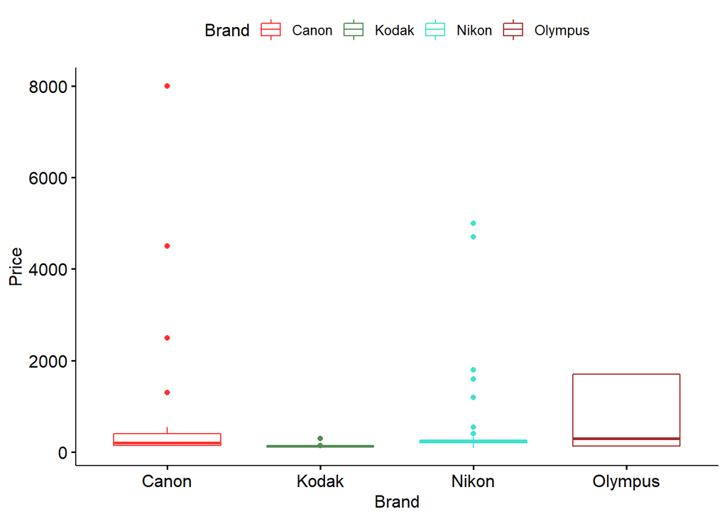

```r
ggboxplot(camera, x = "Brand", y = "Price",
          color = "Brand", palette = c("firebrick1","palegreen4","turquoise","brown"),
          order = c("Canon", "Kodak", "Nikon", "Olympus"),
          ylab = "Price", xlab = "Brand")
```

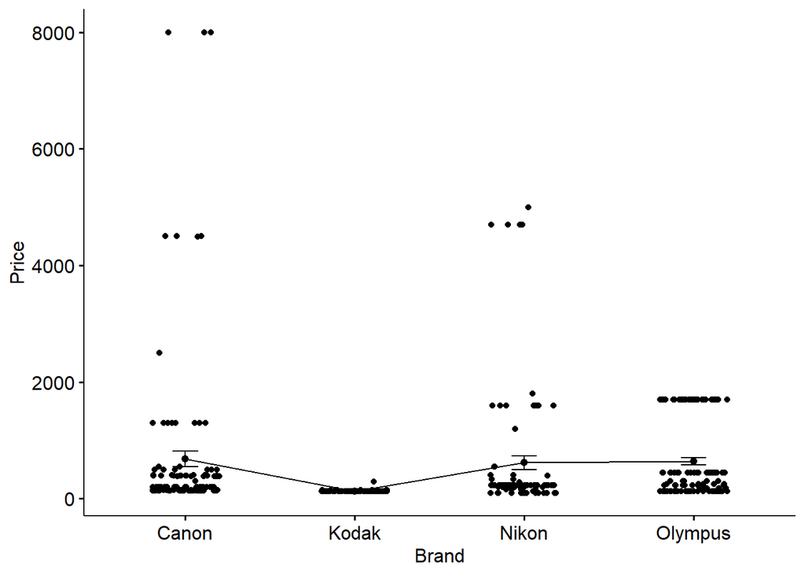

```r
ggline(camera, x = "Brand", y = "Price",
       add = c("mean_se", "jitter"),
       order = c("Canon", "Kodak", "Nikon", "Olympus"),
       ylab = "Price", xlab = "Brand")
```

```r
shapiro.test(camera2$Price)
```

```
##
##  Shapiro-Wilk normality test
##
## data:  camera2$Price
## W = 0.42957, p-value < 2.2e-16
```

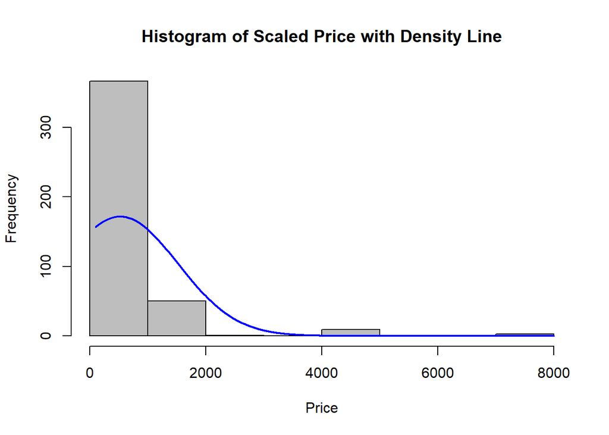

```r
plotNormalHistogram(camera$Price, main = "Histogram of Scaled Price with Density Line", xlab = "Price")
```

Distribution of price is not normal.

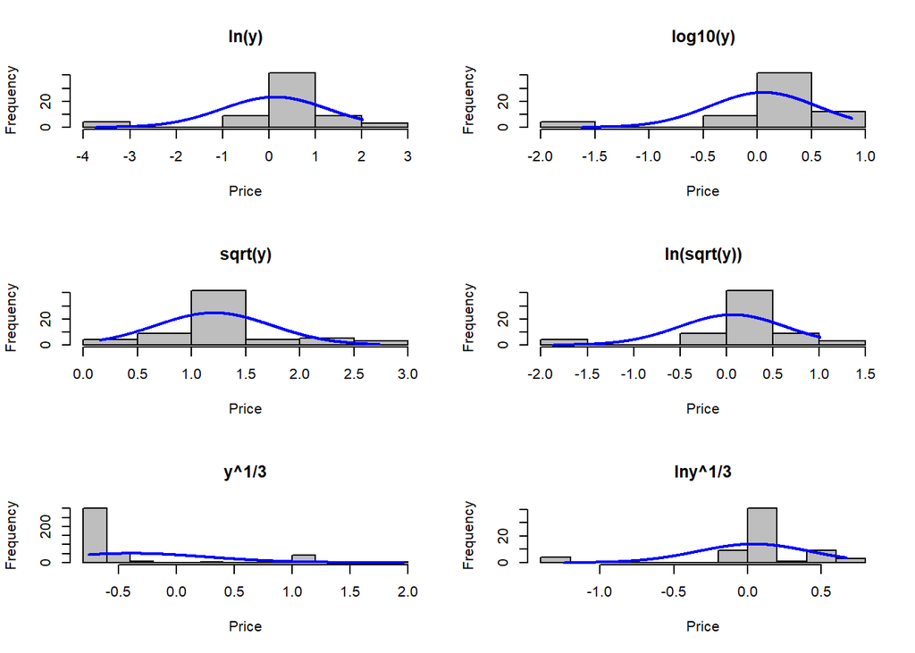

```r
par(mfrow = c(3,2))
plotNormalHistogram(log(camera2$Price), main = "ln(y)", xlab = "Price")
plotNormalHistogram(log10(camera2$Price), main = "log10(y)", xlab = "Price")
plotNormalHistogram(sqrt(camera2$Price), main = "sqrt(y)", xlab = "Price")
plotNormalHistogram(log(sqrt(camera2$Price)), main = "ln(sqrt(y))", xlab = "Price")
plotNormalHistogram(sign(camera2$Price) * abs(camera2$Price)^(1/3), main = "y^1/3", xlab = "Price")
plotNormalHistogram((log((sign(camera2$Price) * abs(camera2$Price))^(1/3))), main = "lny^1/3", xlab = "Price")
```

Transformations did not make the distribution of price normal.

```r
price_tukey = transformTukey(camera$Price,plotit=F)
```

```
##
##     lambda      W Shapiro.p.value
## 355  -1.15 0.9012       4.659e-16
##
## if (lambda >  0){TRANS = x ^ lambda}
## if (lambda == 0){TRANS = log(x)}
## if (lambda <  0){TRANS = -1 * x ^ lambda}
```

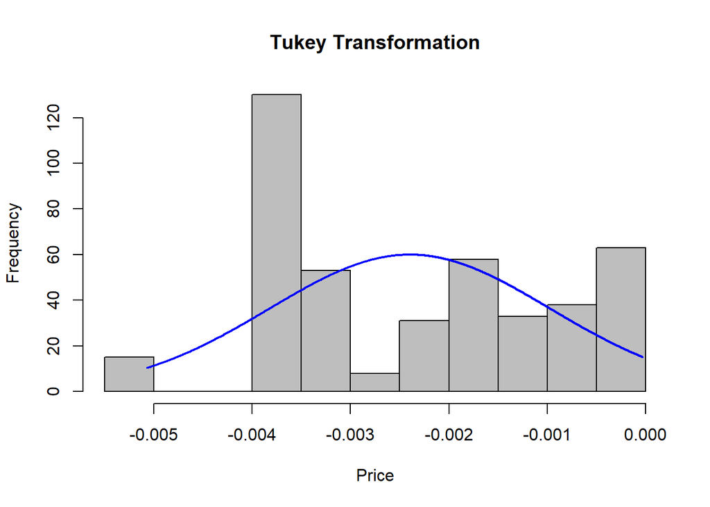

```r
plotNormalHistogram(price_tukey, main = "Tukey Transformation", xlab = "Price")
```

```r
shapiro.test(-1*camera$Price^(-1.15))
```

```
##
##  Shapiro-Wilk normality test
##
## data:  -1 * camera$Price^(-1.15)
## W = 0.90118, p-value = 4.659e-16
```

Tukey transformation did not work either.

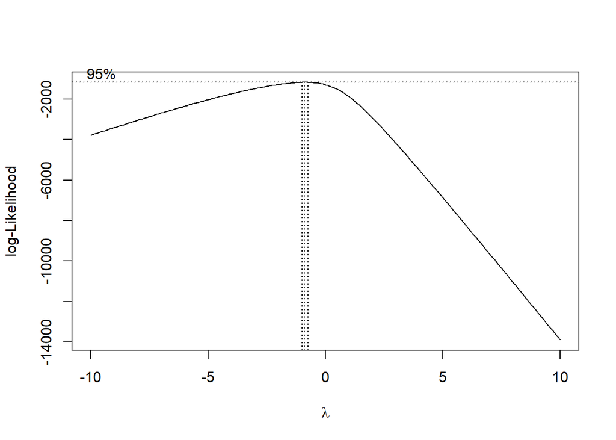

```r
Box = boxcox(camera$Price~1,lambda = seq(-10,10,0.1))
```

```r
Cox = data.frame(Box$x, Box$y)
Cox2 = Cox[with(Cox, order(-Cox$Box.y)),]
Cox2[1,]
```

```
##    Box.x     Box.y
## 92  -0.9 -1170.294
```

```r
lambda = Cox2[1, "Box.x"]
lambda
```

```
## [1] -0.9
```

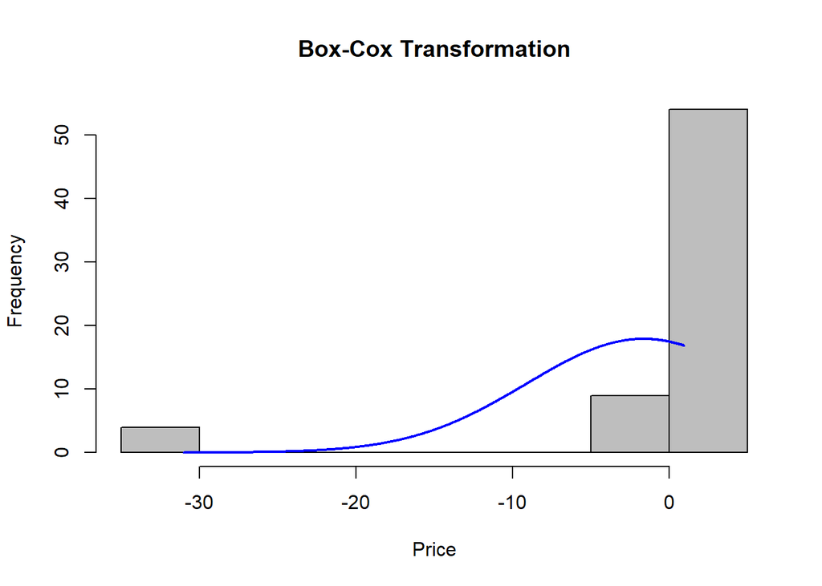

```r
price_box = (camera2$Price ^ lambda - 1)/lambda
plotNormalHistogram(price_box, main = "Box-Cox Transformation", xlab = "Price")
```

```r
shapiro.test(price_box)
```

```
##
##  Shapiro-Wilk normality test
##
## data:  price_box
## W = 0.28854, p-value = 2.305e-16
```

Box-Cox transformation did not work.

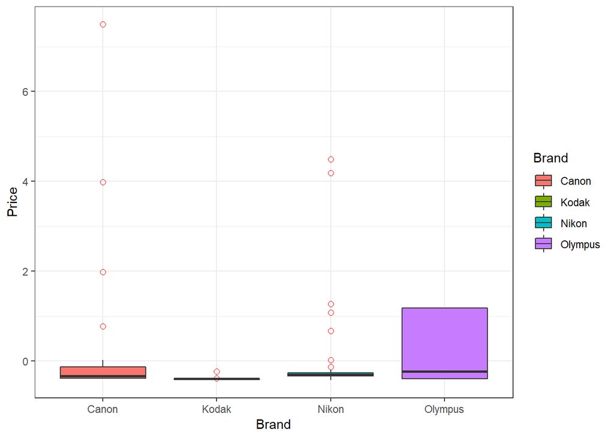

```r
par(mfrow = c(1,11))
ggplot(data = camera2, aes(x = Brand, y = Price, fill = Brand)) +
  geom_boxplot(outlier.colour="red", outlier.shape=1,outlier.size=2) + theme_bw()
```

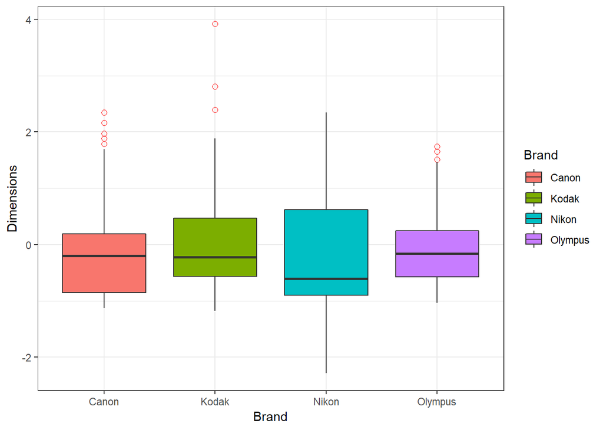

```r
ggplot(data = camera2, aes(x = Brand, y = Dimensions, fill = Brand)) +
  geom_boxplot(outlier.colour="red", outlier.shape=1,outlier.size=2) + theme_bw()
```

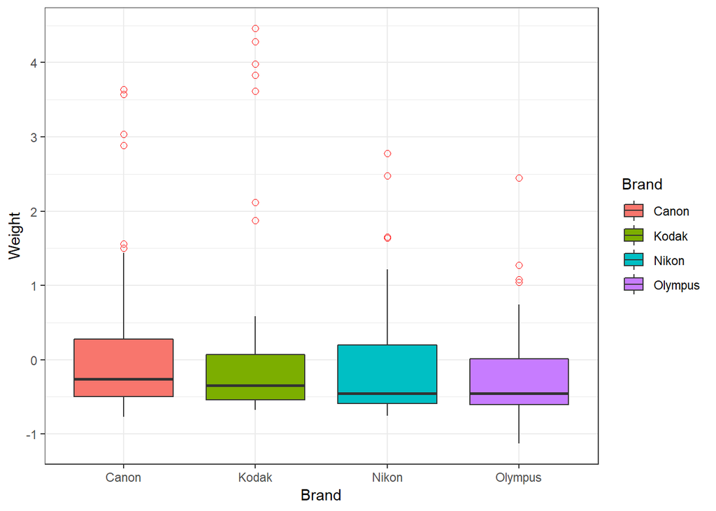

```r
ggplot(data = camera2, aes(x = Brand, y = Weight, fill = Brand)) +
  geom_boxplot(outlier.colour="red", outlier.shape=1,outlier.size=2) + theme_bw()
```

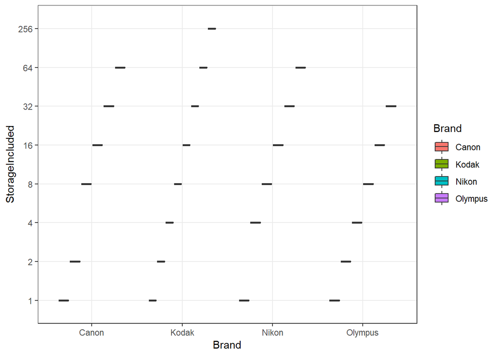

```r
ggplot(data = camera2, aes(x = Brand, y = StorageIncluded, fill = Brand)) +
  geom_boxplot(outlier.colour="red", outlier.shape=1,outlier.size=2) + theme_bw()
```

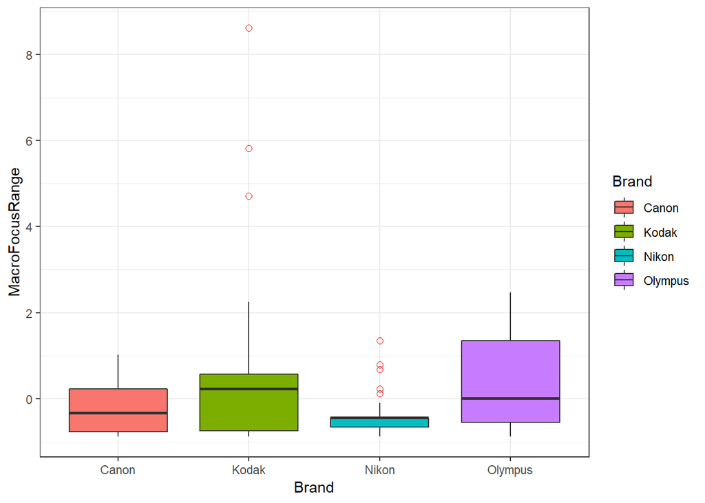

```r
ggplot(data = camera2, aes(x = Brand, y = MacroFocusRange, fill = Brand)) +
  geom_boxplot(outlier.colour="red", outlier.shape=1,outlier.size=2) + theme_bw()
```

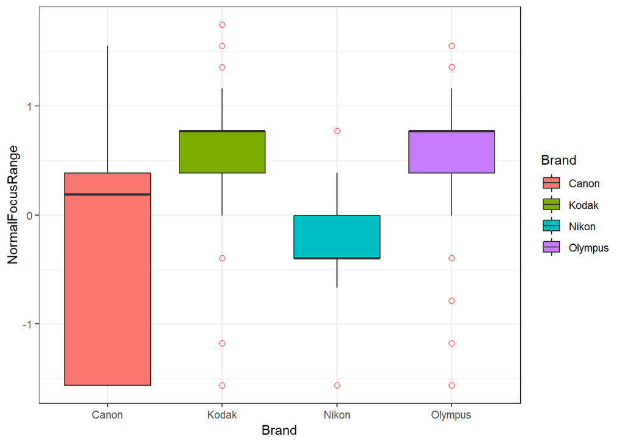

```r
ggplot(data = camera2, aes(x = Brand, y = NormalFocusRange, fill = Brand)) +
  geom_boxplot(outlier.colour="red", outlier.shape=1,outlier.size=2) + theme_bw()
```

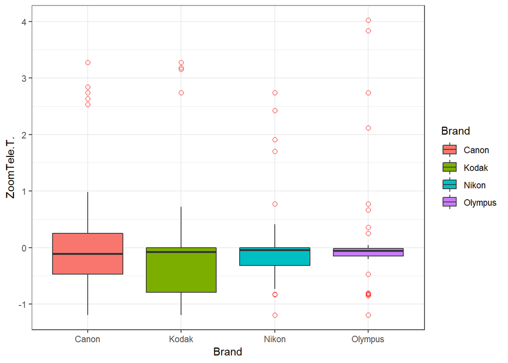

```r
ggplot(data = camera2, aes(x = Brand, y = ZoomTele.T., fill = Brand)) +
  geom_boxplot(outlier.colour="red", outlier.shape=1,outlier.size=2) + theme_bw()
```

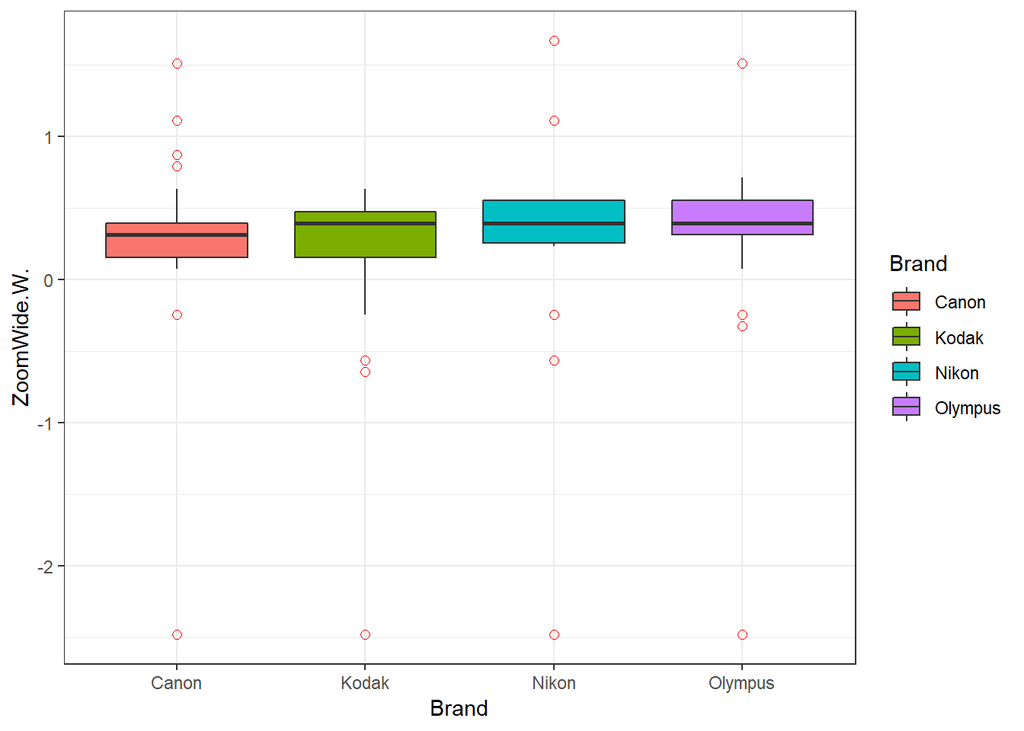

```r
ggplot(data = camera2, aes(x = Brand, y = ZoomWide.W., fill = Brand)) +
  geom_boxplot(outlier.colour="red", outlier.shape=1,outlier.size=2) + theme_bw()
```

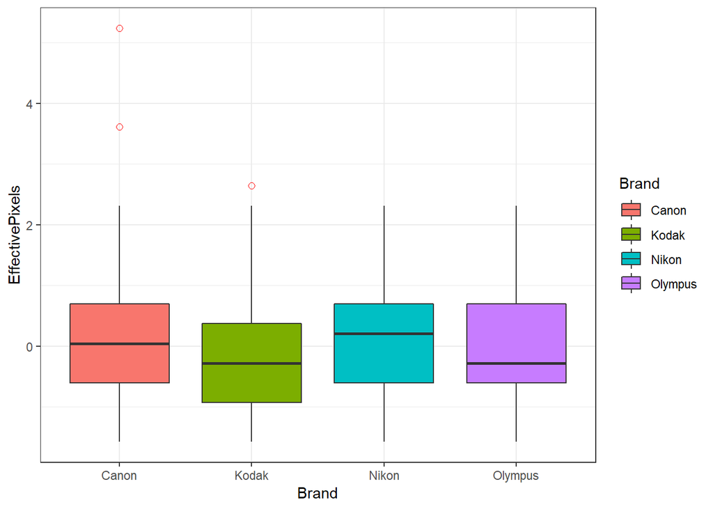

```r
ggplot(data = camera2, aes(x = Brand, y = EffectivePixels, fill = Brand)) +
  geom_boxplot(outlier.colour="red", outlier.shape=1,outlier.size=2) + theme_bw()
```

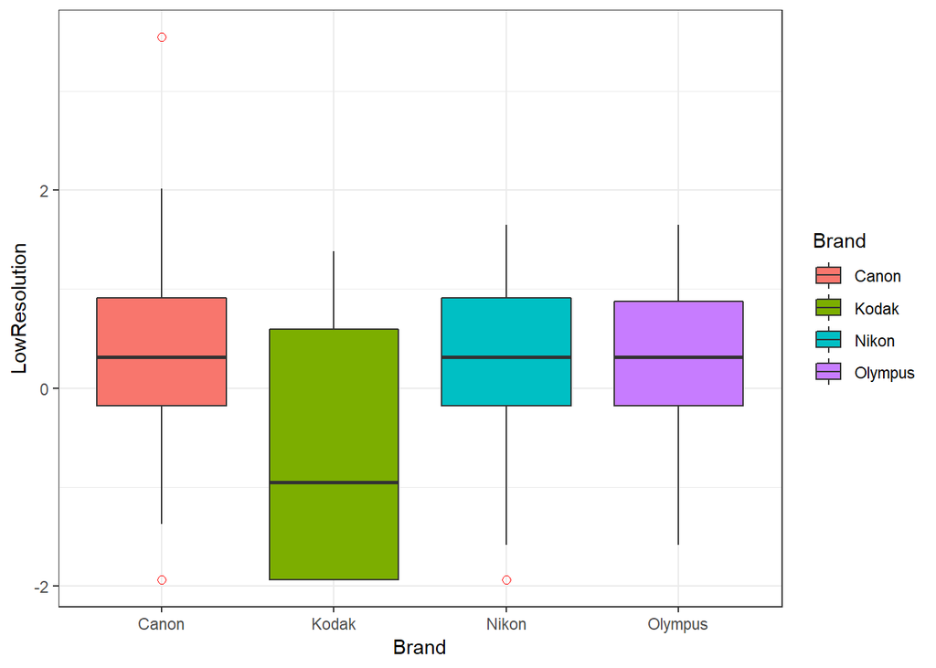

```r
ggplot(data = camera2, aes(x = Brand, y = LowResolution, fill = Brand)) +
  geom_boxplot(outlier.colour="red", outlier.shape=1,outlier.size=2) + theme_bw()
```

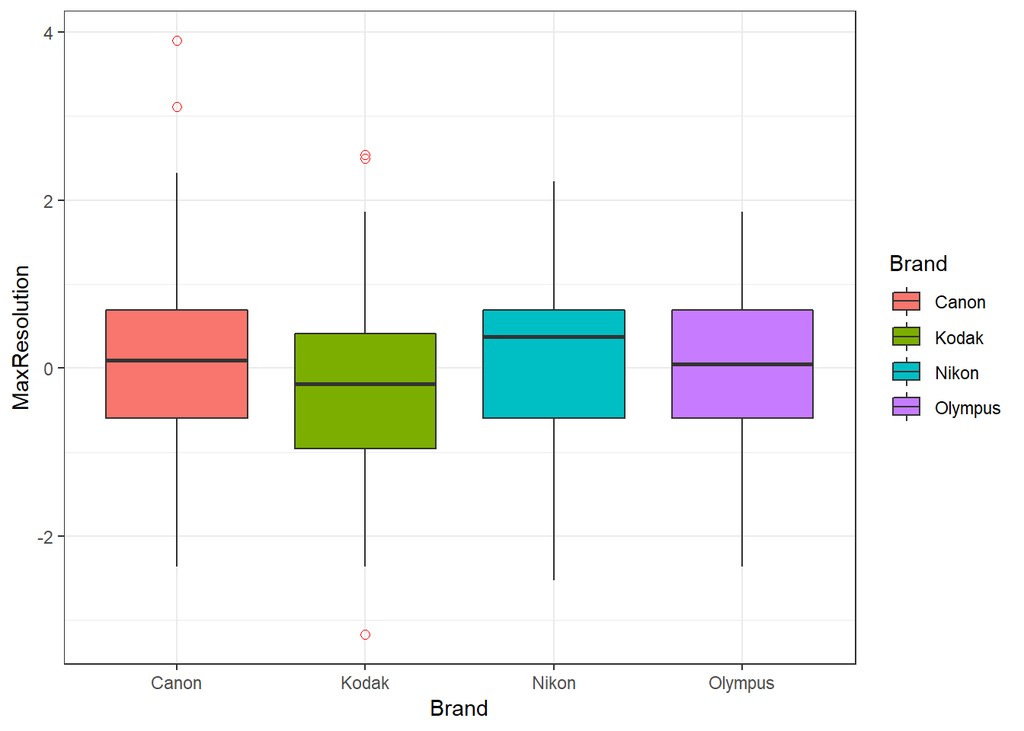

```r
ggplot(data = camera2, aes(x = Brand, y = MaxResolution, fill = Brand)) +
  geom_boxplot(outlier.colour="red", outlier.shape=1,outlier.size=2) + theme_bw()
```

Distributions of features according to different brands.

Are the average prices of all brands equal? 𝐻0: Mean prices of all brands are equal. 𝐻1: At least one of them is different.

```r
anova <- aov(Price ~ Brand, data = camera2 )
summary(anova)
```

```
##              Df Sum Sq Mean Sq F value   Pr(>F)
## Brand         3   21.2   7.058   7.373 7.95e-05 ***
## Residuals   425  406.8   0.957
## ---
## Signif. codes:  0 '***' 0.001 '**' 0.01 '*' 0.05 '.' 0.1 ' ' 1
```

```r
TukeyHSD(anova)
```

```
##   Tukey multiple comparisons of means
##     95% family-wise confidence level
##
## Fit: aov(formula = Price ~ Brand, data = camera2)
##
## $Brand
##                      diff        lwr        upr     p adj
## Kodak-Canon   -0.55285571 -0.8960820 -0.2096294 0.0002300
## Nikon-Canon   -0.06424579 -0.4193914  0.2908998 0.9663123
## Olympus-Canon -0.04319374 -0.3711720  0.2847845 0.9864969
## Nikon-Kodak    0.48860992  0.1236636  0.8535562 0.0034018
## Olympus-Kodak  0.50966197  0.1710957  0.8482282 0.0006898
## Olympus-Nikon  0.02105205 -0.3295920  0.3716961 0.9986760
```

```r
summary(glht(anova, linfct = mcp(Brand = "Tukey")))
```

```
##
##   Simultaneous Tests for General Linear Hypotheses
##
## Multiple Comparisons of Means: Tukey Contrasts
##
##
## Fit: aov(formula = Price ~ Brand, data = camera2)
##
## Linear Hypotheses:
##                      Estimate Std. Error t value Pr(>|t|)
## Kodak - Canon == 0   -0.55286    0.13307  -4.155  < 0.001 ***
## Nikon - Canon == 0   -0.06425    0.13769  -0.467  0.96626
## Olympus - Canon == 0 -0.04319    0.12716  -0.340  0.98647
## Nikon - Kodak == 0    0.48861    0.14149   3.453  0.00343 **
## Olympus - Kodak == 0  0.50966    0.13127   3.883  < 0.001 ***
## Olympus - Nikon == 0  0.02105    0.13595   0.155  0.99867
## ---
## Signif. codes:  0 '***' 0.001 '**' 0.01 '*' 0.05 '.' 0.1 ' ' 1
## (Adjusted p values reported -- single-step method)
```

```r
pairwise.t.test(camera2$Price, camera2$Brand, p.adj="bonferroni")
```

```
##
##  Pairwise comparisons using t tests with pooled SD
##
## data:  camera2$Price and camera2$Brand
##
##         Canon   Kodak   Nikon
## Kodak   0.00024 -       -
## Nikon   1.00000 0.00366 -
## Olympus 1.00000 0.00072 1.00000
##
## P value adjustment method: bonferroni
```

Result of ANOVA says they are not equal. Tukey Comparison Test shows the different one is Kodak. Still assumptions of ANOVA should be checked.

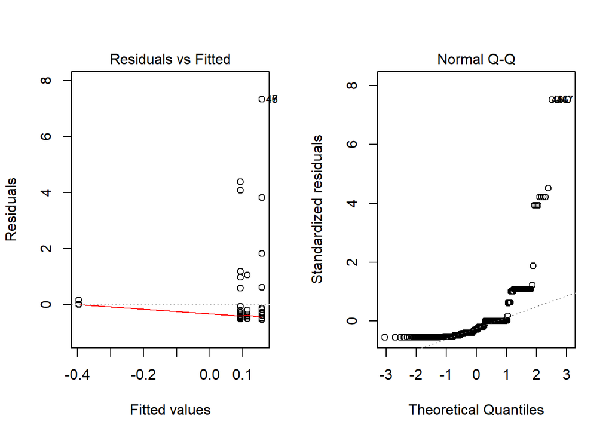

```r
par(mfrow = c(1,2))
plot(anova,1)
plot(anova,2)
```

```r
levene.test(camera2$Price,camera2$Brand, location = "median")
```

```
##
##  Modified robust Brown-Forsythe Levene-type test based on the
##  absolute deviations from the median
##
## data:  camera2$Price
## Test Statistic = 6.7078, p-value = 0.0001973
```

```r
bartlett.test(camera2$Price,camera2$Brand)
```

```
##
##  Bartlett test of homogeneity of variances
##
## data:  camera2$Price and camera2$Brand
## Bartlett's K-squared = 797.26, df = 3, p-value < 2.2e-16
```

```r
shapiro.test(anova$residuals)
```

```
##
##  Shapiro-Wilk normality test
##
## data:  anova$residuals
## W = 0.50332, p-value < 2.2e-16
```

Residuals are not normally distributed and variance is not constant. Assumptions are not satisfied. Non-parametric approaches should be used.

```r
kruskal.test(Price ~ Brand, data = camera2)
```

```
##
##  Kruskal-Wallis rank sum test
##
## data:  Price by Brand
## Kruskal-Wallis chi-squared = 158.59, df = 3, p-value < 2.2e-16
```

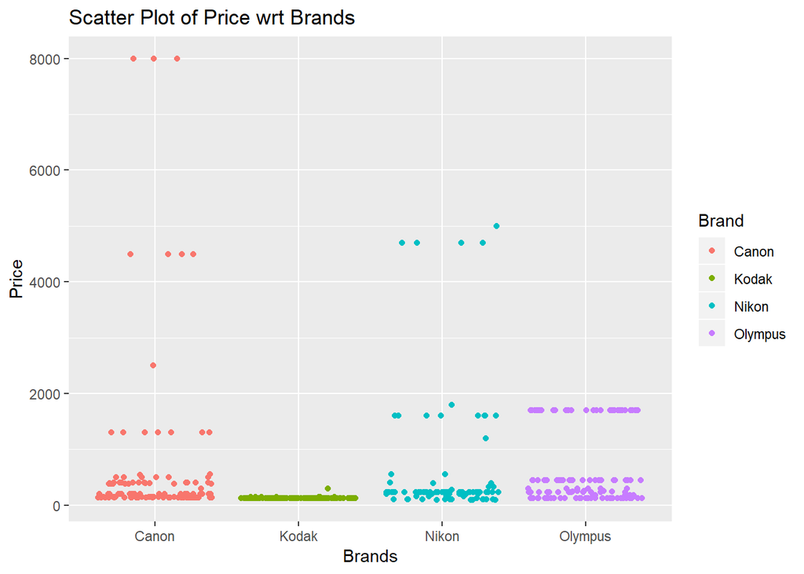

```r
ggplot(data = camera, aes(x = Brand, y = Price, col = Brand)) +
  labs(title = "Scatter Plot of Price wrt Brands", x = "Brands", y="Price") + geom_jitter()
```

Non-parametric approach gave the same result. Therefore we can say Kodak has the different in mean.

What are the variables that affect the price of the product most and least?

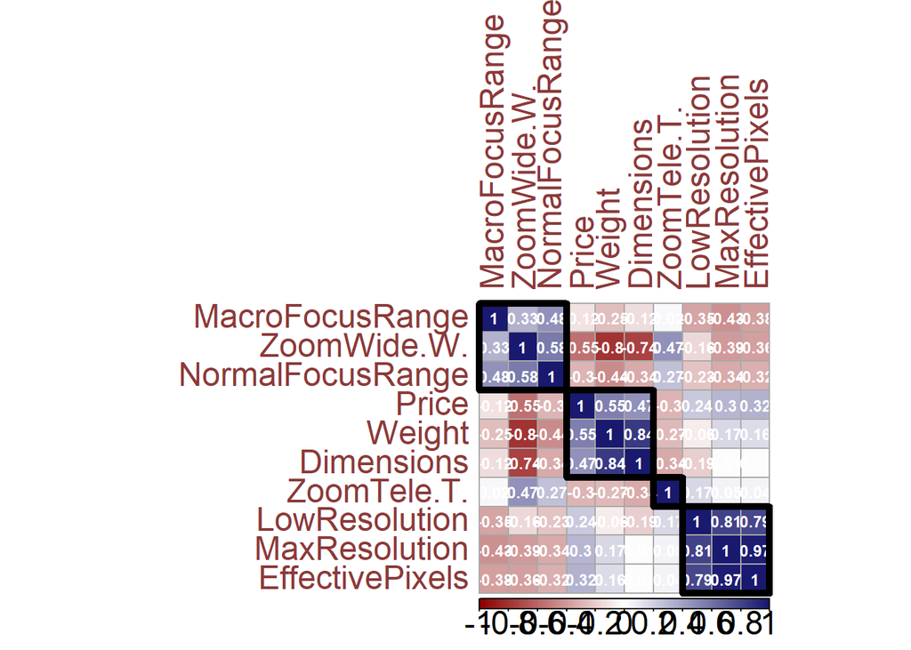

```r
camera.cor <- cor(camera2[,3:12])
corrplot(camera.cor, method = "color", outline = T, addgrid.col = "darkgrey", order = "hclust",
         addrect = 4, rect.col = "black", rect.lwd = 5, cl.pos = "b", tl.col = "indianred4",
         tl.cex = 1.5, cl.cex = 1.5, addCoef.col = "white",number.digits = 2, number.cex = 0.75,
         col = colorRampPalette(c("darkred","white","midnightblue"))(100))
```

According to correlation plot, there is a strong positive relationship between weight and dimensions. Their correlation is 0.84. Also, low resolution and max resolution are highly correlated. Their correlation is 0.81. There is also strong positive relationship between max resolution and effective pixels. Their correlation is 0.97 and it is so close to 1. Moreover, there is a strong negative relationship between weight and zoom wide. Their correlation is -0.8. Dimensions and zoom wide are highly correlated negatively. Their correlation is -0.74. Finally, weight and zoom wide affect the price most. There is a positive relationship between weight and price. Their correlation is 0.55. Also, there is negative relationship between zoom wide and price. Their correlation is -0.55. Macro focus range affects the price the least. Their correlation is -0.12.

```r
summary(camera2$Price)
```

```
##    Min. 1st Qu.  Median    Mean 3rd Qu.    Max.
## -0.4273 -0.3972 -0.3271  0.0000 -0.1266  7.4923
```

```r
binary.price <- ifelse(camera2$Price > -0.3271, 1,0)
sum(binary.price)
```

```
## [1] 223
```

```r
camera3 <- cbind(camera2,binary.price)
str(camera3)
```

```
## 'data.frame':    429 obs. of  13 variables:
##  $ Brand           : Factor w/ 4 levels "Canon","Kodak",..: 1 1 1 1 1 1 1 1 1 1 ...
##  $ StorageIncluded : Factor w/ 8 levels "1","2","4","8",..: 2 1 4 4 4 4 4 6 1 4 ...
##  $ MaxResolution   : num  -2.37 -2.12 -1.56 -1.56 -1.16 ...
##  $ LowResolution   : num  -1.939 -1.236 -0.814 -0.814 -0.814 ...
##  $ EffectivePixels : num  -1.58 -1.58 -1.25 -1.25 -1.25 ...
##  $ ZoomWide.W.     : num  0.872 1.511 0.314 0.633 0.314 ...
##  $ ZoomTele.T.     : num  -0.761 -0.678 -0.108 -0.792 -0.108 ...
##  $ NormalFocusRange: num  1.16225 -0.00626 1.39595 -0.78527 1.39595 ...
##  $ MacroFocusRange : num  -0.547 0.235 0.906 -0.323 0.906 ...
##  $ Weight          : num  -0.16862 0.25225 -0.00328 -0.45421 -0.00328 ...
##  $ Dimensions      : num  -0.7584 2.3446 0.0289 0.0289 0.0289 ...
##  $ Price           : num  -0.377 -0.387 -0.387 -0.387 -0.387 ...
##  $ binary.price    : num  0 0 0 0 0 0 0 0 0 0 ...
```

```r
camera3 <- camera3[,-12]
camera3[,12] <- as.factor(camera3[,12])
str(camera3)
```

```
## 'data.frame':    429 obs. of  12 variables:
##  $ Brand           : Factor w/ 4 levels "Canon","Kodak",..: 1 1 1 1 1 1 1 1 1 1 ...
##  $ StorageIncluded : Factor w/ 8 levels "1","2","4","8",..: 2 1 4 4 4 4 4 6 1 4 ...
##  $ MaxResolution   : num  -2.37 -2.12 -1.56 -1.56 -1.16 ...
##  $ LowResolution   : num  -1.939 -1.236 -0.814 -0.814 -0.814 ...
##  $ EffectivePixels : num  -1.58 -1.58 -1.25 -1.25 -1.25 ...
##  $ ZoomWide.W.     : num  0.872 1.511 0.314 0.633 0.314 ...
##  $ ZoomTele.T.     : num  -0.761 -0.678 -0.108 -0.792 -0.108 ...
##  $ NormalFocusRange: num  1.16225 -0.00626 1.39595 -0.78527 1.39595 ...
##  $ MacroFocusRange : num  -0.547 0.235 0.906 -0.323 0.906 ...
##  $ Weight          : num  -0.16862 0.25225 -0.00328 -0.45421 -0.00328 ...
##  $ Dimensions      : num  -0.7584 2.3446 0.0289 0.0289 0.0289 ...
##  $ binary.price    : Factor w/ 2 levels "0","1": 1 1 1 1 1 1 1 1 1 1 ...
```

```r
input_ones <- camera3[which(camera3$binary.price == 1),]
input_zeros <- camera3[which(camera3$binary.price == 0),]
set.seed(364)
ones_train_rows <- sample(1:nrow(input_ones), 0.8*nrow(input_ones))
zeros_train_rows <- sample(1:nrow(input_zeros), 0.8*nrow(input_zeros))
train_ones <- input_ones[ones_train_rows,]
train_zeros <- input_zeros[zeros_train_rows,]
training_set <- rbind(train_ones,train_zeros)
test_ones <-  input_ones[-ones_train_rows,]
test_zeros <- input_zeros[-zeros_train_rows,]
test_set <- rbind(test_ones,test_zeros)
logitMod <- glm(binary.price ~. ,data = training_set, family = "binomial")
logitMod_2 <- glm(binary.price ~ Brand + MaxResolution +  LowResolution + EffectivePixels + ZoomWide.W. +
                    ZoomTele.T. + NormalFocusRange + MacroFocusRange + Weight + Dimensions,
                    family = "binomial",  data = training_set)
summary(logitMod)
```

```
##
## Call:
## glm(formula = binary.price ~ ., family = "binomial", data = training_set)
##
## Deviance Residuals:
##      Min        1Q    Median        3Q       Max
## -2.04548  -0.00008   0.04411   0.84659   1.66437
##
## Coefficients:
##                      Estimate Std. Error z value Pr(>|z|)
## (Intercept)         8.082e-01  7.691e-01   1.051   0.2933
## BrandKodak         -2.880e+01  1.892e+03  -0.015   0.9879
## BrandNikon          9.049e-01  3.918e-01   2.309   0.0209 *
## BrandOlympus        5.914e-01  3.973e-01   1.488   0.1367
## StorageIncluded2   -1.591e+00  1.613e+00  -0.987   0.3238
## StorageIncluded4    9.263e-02  1.213e+00   0.076   0.9391
## StorageIncluded8   -4.372e-01  8.133e-01  -0.538   0.5908
## StorageIncluded16   9.373e-02  7.993e-01   0.117   0.9066
## StorageIncluded32  -1.231e-01  8.137e-01  -0.151   0.8797
## StorageIncluded64   1.333e+01  1.344e+03   0.010   0.9921
## StorageIncluded256  5.138e+01  1.783e+04   0.003   0.9977
## MaxResolution      -1.179e+00  9.875e-01  -1.194   0.2325
## LowResolution       1.187e+00  5.869e-01   2.022   0.0432 *
## EffectivePixels     4.649e-01  8.250e-01   0.564   0.5731
## ZoomWide.W.        -8.765e-01  5.435e-01  -1.613   0.1068
## ZoomTele.T.        -1.447e-01  2.105e-01  -0.688   0.4918
## NormalFocusRange   -2.287e-01  2.011e-01  -1.137   0.2554
## MacroFocusRange     3.769e-01  2.856e-01   1.320   0.1870
## Weight              8.396e-01  7.004e-01   1.199   0.2306
## Dimensions          1.905e-01  3.243e-01   0.588   0.5569
## ---
## Signif. codes:  0 '***' 0.001 '**' 0.01 '*' 0.05 '.' 0.1 ' ' 1
##
## (Dispersion parameter for binomial family taken to be 1)
##
##     Null deviance: 473.54  on 341  degrees of freedom
## Residual deviance: 281.70  on 322  degrees of freedom
## AIC: 321.7
##
## Number of Fisher Scoring iterations: 19
```

```r
summary(logitMod_2)
```

```
##
## Call:
## glm(formula = binary.price ~ Brand + MaxResolution + LowResolution +
##     EffectivePixels + ZoomWide.W. + ZoomTele.T. + NormalFocusRange +
##     MacroFocusRange + Weight + Dimensions, family = "binomial",
##     data = training_set)
##
## Deviance Residuals:
##     Min       1Q   Median       3Q      Max
## -1.8376  -0.4108   0.1430   0.8711   3.7672
##
## Coefficients:
##                  Estimate Std. Error z value Pr(>|z|)
## (Intercept)       0.59240    0.27339   2.167   0.0302 *
## BrandKodak       -5.71134    1.30606  -4.373 1.23e-05 ***
## BrandNikon        0.79065    0.36489   2.167   0.0302 *
## BrandOlympus      0.42958    0.36317   1.183   0.2369
## MaxResolution    -0.52469    0.84571  -0.620   0.5350
## LowResolution     0.81160    0.51078   1.589   0.1121
## EffectivePixels   0.15366    0.70998   0.216   0.8287
## ZoomWide.W.      -0.73632    0.44418  -1.658   0.0974 .
## ZoomTele.T.      -0.03777    0.19477  -0.194   0.8462
## NormalFocusRange -0.16625    0.18497  -0.899   0.3688
## MacroFocusRange   0.30353    0.23622   1.285   0.1988
## Weight            0.28091    0.47895   0.587   0.5575
## Dimensions        0.25599    0.29474   0.869   0.3851
## ---
## Signif. codes:  0 '***' 0.001 '**' 0.01 '*' 0.05 '.' 0.1 ' ' 1
##
## (Dispersion parameter for binomial family taken to be 1)
##
##     Null deviance: 473.54  on 341  degrees of freedom
## Residual deviance: 302.63  on 329  degrees of freedom
## AIC: 328.63
##
## Number of Fisher Scoring iterations: 7
```

```r
anova(logitMod, test = "Chisq")
```

```
## Analysis of Deviance Table
##
## Model: binomial, link: logit
##
## Response: binary.price
##
## Terms added sequentially (first to last)
##
##
##                  Df Deviance Resid. Df Resid. Dev  Pr(>Chi)
## NULL                               341     473.54
## Brand             3  138.674       338     334.87 < 2.2e-16 ***
## StorageIncluded   7   32.466       331     302.40 3.328e-05 ***
## MaxResolution     1    0.243       330     302.16 0.6218602
## LowResolution     1    1.747       329     300.41 0.1862886
## EffectivePixels   1    0.001       328     300.41 0.9744746
## ZoomWide.W.       1   12.601       327     287.81 0.0003855 ***
## ZoomTele.T.       1    0.002       326     287.81 0.9617024
## NormalFocusRange  1    0.152       325     287.65 0.6965015
## MacroFocusRange   1    1.866       324     285.79 0.1719536
## Weight            1    3.743       323     282.04 0.0530302 .
## Dimensions        1    0.347       322     281.70 0.5556688
## ---
## Signif. codes:  0 '***' 0.001 '**' 0.01 '*' 0.05 '.' 0.1 ' ' 1
```

```r
anova(logitMod_2, test = "Chisq")
```

```
## Analysis of Deviance Table
##
## Model: binomial, link: logit
##
## Response: binary.price
##
## Terms added sequentially (first to last)
##
##
##                  Df Deviance Resid. Df Resid. Dev  Pr(>Chi)
## NULL                               341     473.54
## Brand             3  138.674       338     334.87 < 2.2e-16 ***
## MaxResolution     1    5.848       337     329.02    0.0156 *
## LowResolution     1    0.025       336     328.99    0.8734
## EffectivePixels   1    0.015       335     328.98    0.9012
## ZoomWide.W.       1   22.140       334     306.84 2.535e-06 ***
## ZoomTele.T.       1    0.013       333     306.82    0.9095
## NormalFocusRange  1    0.151       332     306.67    0.6976
## MacroFocusRange   1    1.632       331     305.04    0.2015
## Weight            1    1.638       330     303.40    0.2006
## Dimensions        1    0.771       329     302.63    0.3799
## ---
## Signif. codes:  0 '***' 0.001 '**' 0.01 '*' 0.05 '.' 0.1 ' ' 1
```

```r
pR2(logitMod)
```

```
##          llh      llhNull           G2     McFadden         r2ML
## -140.8484954 -236.7697060  191.8424210    0.4051245    0.4293292
##         r2CU
##    0.5727592
```

```r
pR2(logitMod_2) #according to McFadden first one is better
```

```
##          llh      llhNull           G2     McFadden         r2ML
## -151.3164911 -236.7697060  170.9064298    0.3609128    0.3933034
##         r2CU
##    0.5246979
```

```r
str(binary.price)
```

```
##  num [1:429] 0 0 0 0 0 0 0 0 0 0 ...
```

```r
pred.train <- predict(logitMod,training_set)
optCutoff <- optimalCutoff(training_set$binary.price,pred.train)
optCutoff
```

```
## [1] 0.1960685
```

```r
predTrain_price <- ifelse(pred.train>optCutoff,1,0)
predTrain_price
```

[output not shown]

[output cut: 23 more lines]

```r
conf_mat.train <- table(predTrain_price,training_set$binary.price)
conf_mat.train
```

```
##
## predTrain_price   0   1
##               0 118  23
##               1  46 155
```

```r
accuracy.train <- (conf_mat.train[1,1]+conf_mat.train[2,2])/(conf_mat.train[1,1]+
                    conf_mat.train[1,2]+conf_mat.train[2,1]+conf_mat.train[2,2])
accuracy.train
```

```
## [1] 0.7982456
```

```r
sensitivity.train <- (conf_mat.train[2,2]) / (conf_mat.train[1,2] + conf_mat.train[2,2])
sensitivity.train
```

```
## [1] 0.8707865
```

```r
specificity.train <- (conf_mat.train[1,1]) / (conf_mat.train[1,1] + conf_mat.train[2,1])
specificity.train
```

```
## [1] 0.7195122
```

```r
misclaser.train <-  misClassError(training_set$binary.price, predTrain_price, threshold = optCutoff)
misclaser.train
```

```
## [1] 0.2018
```

```r
pred.test <- predict(logitMod, test_set)
test.cutoff <- optimalCutoff(test_set$binary.price, pred.test)
test.cutoff
```

```
## [1] 0.1483885
```

```r
predTest_price <- ifelse(pred.test>optCutoff,1,0)
predTest_price
```

```
##  42  43  48  49  56  58  64  65  67  76  87  92  94  97 102 105 106 238
##   1   1   1   1   1   1   1   1   1   1   1   1   1   1   1   0   1   1
## 251 269 270 277 289 290 305 307 311 312 324 329 333 340 341 358 371 375
##   1   1   1   1   1   1   1   1   1   1   1   1   1   1   1   1   1   1
## 406 409 410 417 418 423 424 427 429   4   5   8  13  16  18  22  23  30
##   1   1   1   1   1   1   1   1   1   0   0   1   0   0   1   1   1   1
##  31  37  40  66 121 122 124 125 129 132 135 142 146 161 168 169 170 171
##   1   1   0   1   0   0   0   0   0   0   0   0   0   0   0   0   0   0
## 174 177 190 191 192 198 200 316 319 332 334 343 363 379 390
##   0   0   0   0   0   0   0   1   1   1   1   1   1   0   0
```

```r
conf_mat.test <- table(predTest_price,test_set$binary.price)
conf_mat.test
```

```
##
## predTest_price  0  1
##              0 28  1
##              1 14 44
```

```r
accuracy.test <- (conf_mat.test[1,1]+conf_mat.test[2,2])/(conf_mat.test[1,1]+conf_mat.test[1,2]+
                                                       conf_mat.test[2,1]+conf_mat.test[2,2])
accuracy.test
```

```
## [1] 0.8275862
```

```r
sensitivity.test <- (conf_mat.test[2,2]) / (conf_mat.test[1,2] + conf_mat.test[2,2])
sensitivity.test
```

```
## [1] 0.9777778
```

```r
specificity.test <- (conf_mat.test[1,1]) / (conf_mat.test[1,1] + conf_mat.test[2,1])
specificity.test
```

```
## [1] 0.6666667
```

```r
misclaser.test <-  misClassError(test_set$binary.price, predTest_price, threshold = test.cutoff)
misclaser.test
```

```
## [1] 0.1724
```

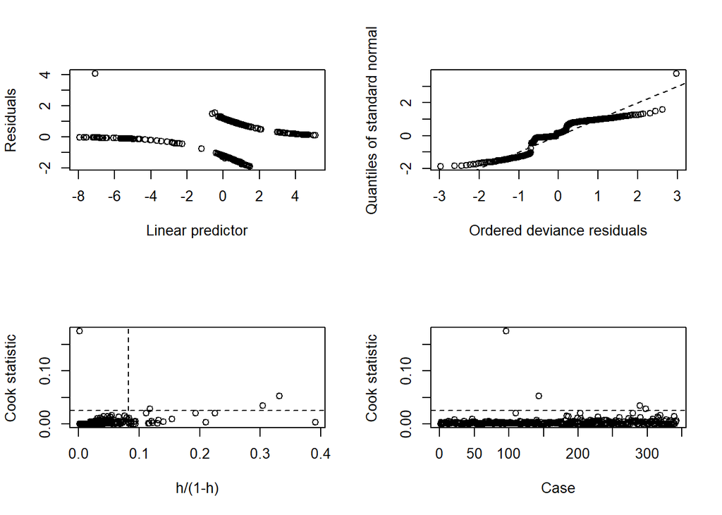

```r
glm.diag.plots(logitMod_2)
```

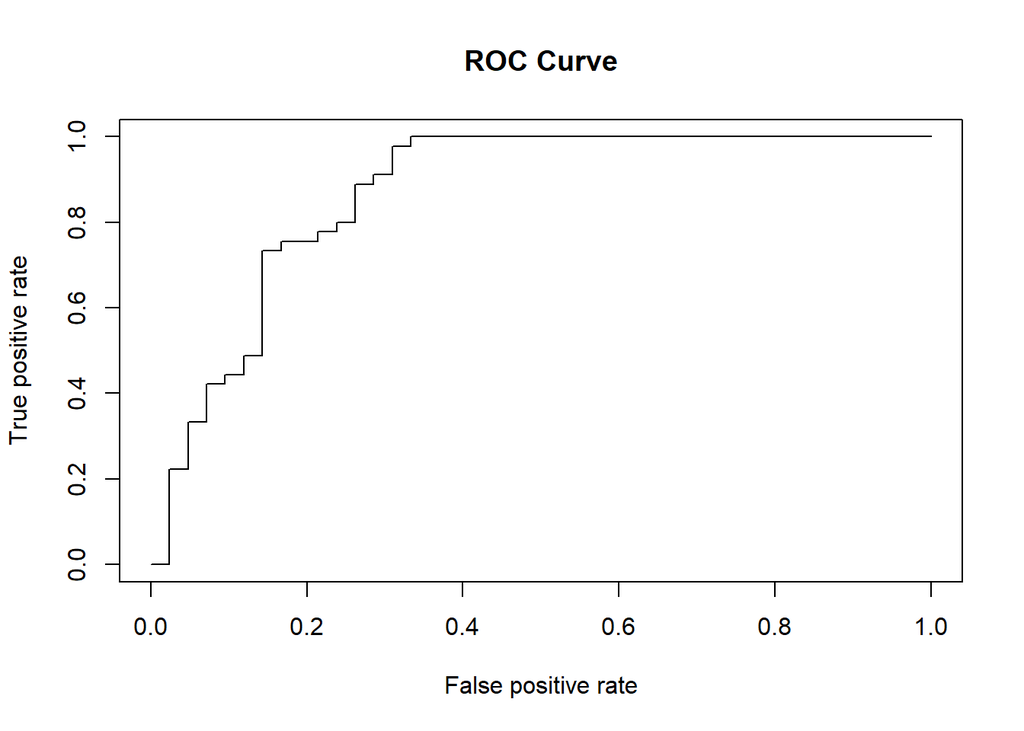

```r
pred <- prediction(pred.test, test_set$binary.price)
perf <- performance(pred, measure = "tpr", x.measure = "fpr")
plot(perf, main = "ROC Curve")
```

```r
area.under.curve <- performance(pred, measure = "auc")
area.under.curve <- area.under.curve@y.values[[1]]
area.under.curve
```

```
## [1] 0.8693122
```

Accuracy with training set is 80% where accuracy with new set is almost 83%. Logistic model works fine. It is better in predicting 1’s than 0’s. Area Under Curve in ROC Curve is approximately 0.87.